# phyloseq Frequently Asked Questions (FAQ)

Paul McMurdie and Susan Holmes

Tue Oct 29 22:09:54 2024

# Contents

This vignette includes answers and supporting materials that address [frequently asked questions (FAQs)](https://en.wikipedia.org/wiki/FAQ), especially those posted on [the phyloseq issues tracker](https://github.com/joey711/phyloseq/issues).

For most issues [the phyloseq issues tracker](https://github.com/joey711/phyloseq/issues) should suffice; but occasionally there are questions that are asked repeatedly enough that it becomes appropriate to canonize the answer here in this vignette. This is both (1) to help users find solutions more quickly, and (2) to mitigate redundancy on [the issues tracker](https://github.com/joey711/phyloseq/issues).

All users are encouraged to perform a google search and review other questions/responses to both open and closed issues on [the phyloseq issues tracker](https://github.com/joey711/phyloseq/issues) before seeking an active response by posting a new issue.

```r
library("phyloseq"); packageVersion("phyloseq")
```

```
## [1] '1.50.0'
```

```r
library("ggplot2"); packageVersion("ggplot2")
```

```
## [1] '3.5.1'
```

```r
theme_set(theme_bw())
```

# 1 - I tried reading my biom file using phyloseq, but it didn’t work. What’s wrong?

The most common cause for this errors is derived from a massive change to the way biom files are stored on disk. There are currently two “versions” of the biom-format, each of which stores data very differently. The original format – and original support in phyloseq – was for biom-format version 1 based on JSON.

The latest version – version 2 – is based on the [HDF5](https://www.hdfgroup.org/HDF5/doc/UG/index.html) file format, and this new biom format version recently become the default file output format for popular workflows like QIIME.

## 1.1 Good News: HDF5-biom should be supported in next release

The *biomformat* package is the Bioconductor incarnation of R package support for the biom file format, written by Paul McMurdie (phyloseq author) and Joseph Paulson (metagenomeSeq author). Although it has been available on GitHub and BioC-devel for many months now, the first release version of *biomformat* on Bioconductor will be in April 2016. In that same release, phyloseq will switch over from the JSON-only *biom* package hosted on CRAN to this new package, *biomformat*, which simultaneously supports biom files based on either HDF5 or JSON.

This difference will be largely opaque to users, and phyloseq will “just work” after the next release in April.

Use the `import_biom` function to read your recent QIIME or other biom-format data.

Additional back details are described in [Issue 443](https://github.com/joey711/phyloseq/issues/443).

## 1.2 HDF5 (Version 2.0) biom-format: *biomformat*

As just described, HDF5 biom format is currently supported in the development version of phyloseq, via the new beta/development package called *biomformat* on BioC-devel and GitHub:

https://github.com/joey711/biomformat

If you need to use HDF5-based biom format files **immediately** and cannot wait for the upcoming release, then you should install the development version of the *biomformat* package by following the instructions at the link above.

## 1.3 Not every data component is included in .biom files

Even though the biom-format supports the self-annotated inclusion of major components like that taxonomy table and sample data table, many tools that generate biom-format files (like QIIME, MG-RAST, mothur, etc.) do not export this data, even if you provided the information in your data input files. The reason for this boggles me, and I’ve shared my views on this with QIIME developers, but there nevertheless seems to be no plan to include your sample data in the ouput biom file.

Furthermore, even though I have proposed it to the biom-format team, there is currently no support (or timeline for support) for inclusion of a phylogenetic tree within a “.biom” file.

A number of tutorials are available demonstrating how one can add components to a phyloseq object after it has been created/imported. The following tutorial is especially relevant

http://joey711.github.io/phyloseq-demo/import-biom-sd-example.html

Which makes use of the following functions:

- `import_qiime_sample_data`
- `merge_phyloseq`

## 1.4 Other issues related the biom-format

There are a number of different Issue Tracker posts discussing this format with respect to phyloseq:

https://github.com/joey711/phyloseq/issues/302

https://github.com/joey711/phyloseq/issues/272

https://github.com/joey711/phyloseq/issues/392

[Issue 443](https://github.com/joey711/phyloseq/issues/443) has details for updated format.

# 2 - `microbio_me_qiime()` returned an error. What’s wrong?

## 2.1 The QIIME-DB Server is Permanently Down.

The QIIME-DB server is permanently down.

Users are suggested to migrate their queries over to Qiita.

Indeed, the previous link to [microbio.me/qiime](http://www.microbio.me/qiime/index.psp) now sends users to the new Qiita website.

## 2.2 An interface to Qiita is Planned.

Stay tuned. The Qiita API needs to be released by the Qiita developers first. The phyloseq developers have no control over this, as we are not affiliated directly with the QIIME developers. Once there is an official Qiita API with documentation, an interface for phyloseq will be added.

We found the `microbio_me_qiime()` function to be very convenient while the QIIME-DB server lasted. Hopefully an equivalent is hosted soon.

# 3 - I want a phyloseq graphic that looks like…

Great!

**Every plot function in phyloseq returns a ggplot2 object**. When these objects are “printed” to standard output in an R session, for instance,

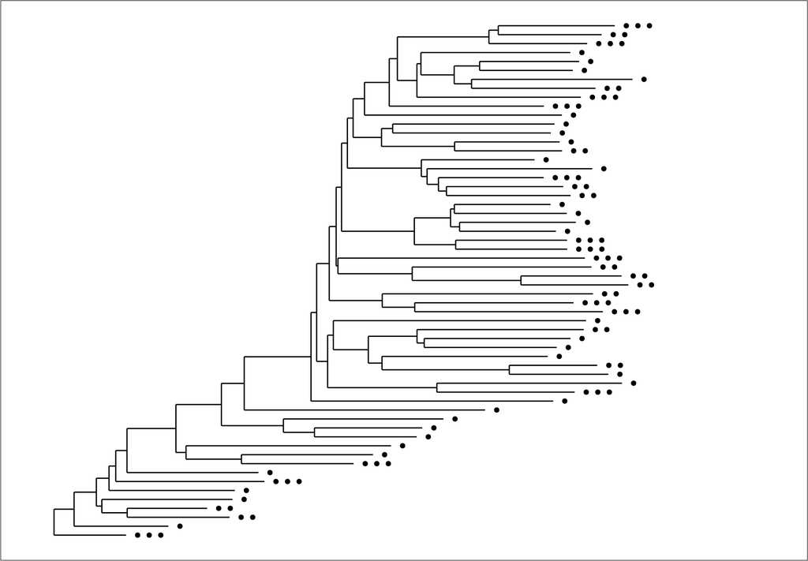

```r
data(esophagus)
plot_tree(esophagus)
```

then the graphic is rendered in [the current graphic device](https://stat.ethz.ch/R-manual/R-devel/library/grDevices/html/Devices.html).

Alternatively, if you save the object output from a phyloseq `plot_` function as a variable in your session, then you can further modify it, interactively, at your leisure. For instance,

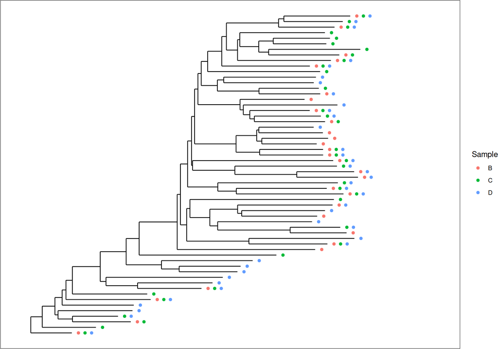

```r
p1 = plot_tree(esophagus, color = "Sample")
p1
```

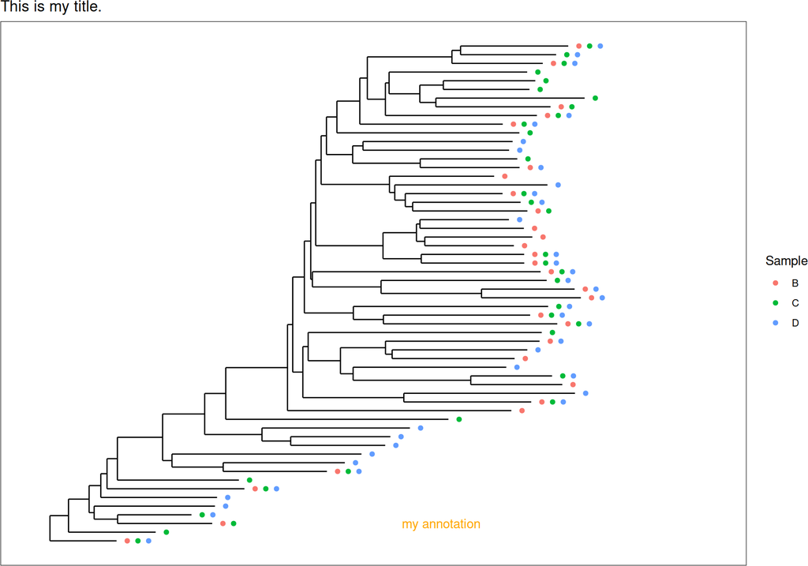

```r
p1 +
  ggtitle("This is my title.") +
  annotate("text", 0.25, 3,
           color = "orange",
           label = "my annotation")
```

There are lots of ways for you to generate custom graphics with phyloseq as a starting point.

The following sections list some of my favorites.

## 3.1 Modify the ggplot object yourself.

For example, [the plot_ordination() examples tutorial](http://joey711.github.io/phyloseq/plot_ordination-examples.html) provides several examples of using additional ggplot2 commands to modify/customize the graphic encoded in the ggplot2 object returned by `plot_ordination`.

[The ggplo2 documentation](http://docs.ggplot2.org/current/) is the current and canonical online reference for creating, modifying, and developing with ggplot2 objects.

For simple changes to aesthetics and aesthetic mapping, [the aesthetic specifications vignette](http://docs.ggplot2.org/current/vignettes/ggplot2-specs.html) is a useful resource.

## 3.2 psmelt and ggplot2

The `psmelt` function converts your phyloseq object into a table (`data.frame`) that is very friendly for defining a custom ggplot2 graphic. This function was originally created as an internal (not user-exposed) tool within phyloseq to enable a [DRY](https://en.wikipedia.org/wiki/Don%27t_repeat_yourself) approach to building ggplot2 graphics from microbiome data represented as phyloseq objects.

When applicable, the phyloseq `plot_` family of functions use `psmelt`. This function is now a documented and user-accessible function in phyloseq – for the main purpose of enabling users to create their own ggplot2 graphics as needed.

There are lots of great documentation examples for ggplot2 at

- [the ggplot2 official documentation site](http://docs.ggplot2.org/current/),
- [ggplot2 on StackOverflow](http://stackoverflow.com/tags/ggplot2), and
- [phyloseq documentation pages](https://joey711.github.io/phyloseq/).

The following are two very simple examples of using `psmelt` to define your own ggplot2 object “from scratch”. It should be evident that you could include further ggplot2 commands to modify each plot further, as you see fit.

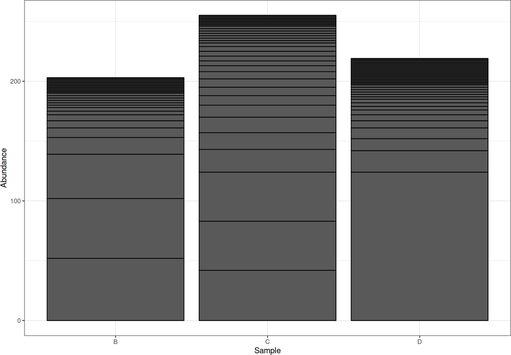

```r
data("esophagus")
mdf = psmelt(esophagus)
# Simple bar plot. See plot_bar() for more.
ggplot(mdf, aes(x = Sample,
                y = Abundance)) +
  geom_bar(stat = "identity", position = "stack", color = "black")
```

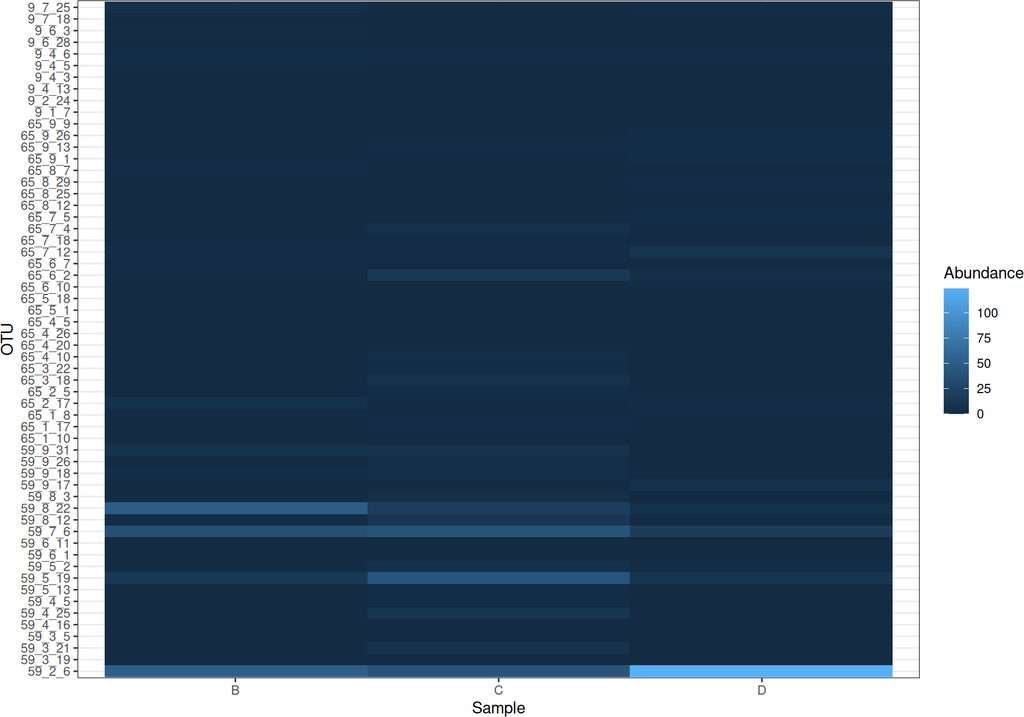

```r
# Simple heat map. See plot_heatmap() for more.
ggplot(mdf, aes(x = Sample,
                y = OTU,
                fill = Abundance)) +
  geom_raster()
```

## 3.3 Submit a Pull Request (Advanced)

If your new custom plot function is awesome and you think others might use it, add it to the `"plot-methods.R"` source file and submit a pull request on GitHub.

[GitHub Official Pull Request Documentation](https://help.github.com/articles/using-pull-requests/)

Please include example and test code in the code included in your pull request.

I’ll try and add it to the package by the next release. I will also give you authorship credit in the function doc. See the “typo fix” section below for further details about GitHub pull requests…

## 3.4 Define a ggplot2 extension (Advanced)

Development of new R functions/commands for creating/modifying new geometric objects is now formally documented in [the ggplot2 extension vignette](http://docs.ggplot2.org/current/vignettes/extending-ggplot2.html).

This may be related to the previous section, in that your ggplot2 extension for phyloseq could be contributed to the phyloseq project as a pull request.

# 4 - There’s a typo in phyloseq documentation, tutorials, or vignettes

This is something that is actually faster and less work for you to solve yourself and contribute back to the phyloseq package. For trivial typo fixes, I will quickly include your fixes into the package code. Sometimes I accept them on my cell phone while I’m still in bed. No wasted time on either end! :-)

The point is that this should be simple, and is simple if you follow one of the following suggestions.

## 4.1 Fix the typo directly on GitHub

GitHub now provides the option to make changes to code/text of a repository directly from your web browser through an in-page editor. This handles all the Git details for you. If you have a GitHub account and you’re logged in, all you’d have to do is locate the file with the offending typo, then use the “edit” button to make the changes and send the to me as a pull request.

## 4.2 Minimal GIT and GitHub Exercise

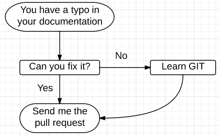

(The following instructions are borrowed from [Yihui Xie’s site about fixing typos](http://yihui.name/en/2013/06/fix-typo-in-documentation/))

Alternatively, for those who want to try GIT and Github pull requests, which make it possible for you to contribute to open source and fix obvious problems with no questions being asked – just do it yourself, and send the changes to the original author(s) through Github.

The official documentation for Github pull requests is a little bit verbose for beginners. Basically what you need to do for simple tasks are:

1. click the Fork button and clone the repository in your own account;
2. make the changes in your cloned version;
3. push to your repository;
4. click the Pull Request button to send a request to the original author;

# 5 - I read [“Waste Not, Want Not…”](http://journals.plos.org/ploscompbiol/article?id=10.1371/journal.pcbi.1003531) but…

Before getting to more specific issues, let’s start by keeping appropriately separate the concept of

- 1. denoising amplicon sequences, and/or denoising features in the contingency table, and
- 2. standardization

These two concepts have been often-conflated – mostly by purveyors of methods that use rarefying – wrongly insisting that rarefying is somehow addressing both problems and the matter is settled. Unfortunately rarefying is a very inefficient, noise-introducing method that poorly addresses the data analysis challenges that motivate either concept.

DESeq2 and related solutions can help you address the need for standardization (e.g. differing library sizes) at a particular step in your analysis while still making efficient inferences from your data.

The denoising problem is best addressed at the sequence-processing level, and the best general-purpose option currently available is:

- [The dada2 algorithm](http://benjjneb.github.io/dada2/), if your data works well with it. Current support is mainly Illumina sequence data, or
- [UPARSE](http://drive5.com/uparse/) in the usearch package, if you don’t have sequencing data that works well with [dada2](http://benjjneb.github.io/dada2/)

## 5.1 I tried to [use DESeq2](http://joey711.github.io/phyloseq-extensions/DESeq2.html) to normalize my data, but now I don’t know what to do…

The answer to a question of this category depends a lot on your experiment, and what you want to learn from your data. The following are some resources that may help.

- [Waste Not, Want Not Supplemental Materials](http://joey711.github.io/waste-not-supplemental/)
- [Differential Abundance Vignette](https://www.bioconductor.org/packages/release/bioc/vignettes/phyloseq/inst/doc/phyloseq-mixture-models.html)
- [The phyloseq front page](https://joey711.github.io/phyloseq/)

## 5.2 My libraries/samples had different total number of reads, what do I do?

That is an expected artifact of current sequencing technologies, and not a “problem” on its own. In most cases, differences in total counts are uncorrelated with any variable in your experimental design. **You should check that this is the case**. It remains possible that there are structural/procedural artifacts in your experiment that have influenced the total counts. If library sizes are correlated with one of your design variables, then this *might* represent an artifact that you need to address more carefully. This is a decision that you will have to make and defend. No software package or workflow can address this for you, but phyloseq/R can certainly help you check for correlation. See the `sample_sums()` and `sample_data()` accessor functions.

Other than the portent of structural biases in your experiment, you should recall that comparisons between observation classes that have **uneven sample sizes is not a new nor unsolved problem in statistics**.

The most useful analytical methods you can use in this context are therefore methods that expect and account for differences in total number of reads between samples.

How you account for these *library size* differences should depend on the type of analysis in which you are engaged, and which methods you plan to use. For instance, for a beta-diversity measure like Bray-Curtis Dissimilarity, you might simply use the relative abundance of each taxa in each sample, as the absolute counts are not appropriate to use directly in the context where count differences are not meaningful.

For further information, see

- [“Waste Not, Want Not…”](http://journals.plos.org/ploscompbiol/article?id=10.1371/journal.pcbi.1003531)
- [Discussion for Issue 229](https://github.com/joey711/phyloseq/issues/229)
- [Discussion for Issue 299](https://github.com/joey711/phyloseq/issues/299)

## 5.3 Should I normalize my data before alpha-diversity analysis

**No.** Generally speaking, the answer is **no**. Most alpha diversity methods will be most effective when provided with the originally-observed count values.

The misleading notion – that normalization is necessary prior to alpha-diversity analysis – seems to be derived from various “one size fits all” pipeline tools like QIIME, in which it is often encouraged to [*rarefy*](http://journals.plos.org/ploscompbiol/article?id=10.1371/journal.pcbi.1003531) counts as a normalizing transformation prior to any/all analysis. While this may simplify certain aspects of pipeline software development, it is analytical and statistical folly. **Rarefying microbiome data is statistically inadmissible**.

For further information, I suggest reviewing literature such as

- [Gotelli Colwell (2001)](http://onlinelibrary.wiley.com/doi/10.1046/j.1461-0248.2001.00230.x/abstract;jsessionid=A5EF264ABB5EADD5CCE9EF3AEE50CA41.f01t03), and of course,
- [“Waste Not, Want Not…”](http://journals.plos.org/ploscompbiol/article?id=10.1371/journal.pcbi.1003531)

## 5.4 Negative numbers in my transformed data table?

This sort of question usually appears after someone used a log-like transformation / variance stabilizing transformation on their data, in preparation for an exploratory analysis via ordination. Negative values in this context probably correspond to **“less than one count”** after rescaling. For many ordination methods, like [PCA](https://en.wikipedia.org/wiki/Principal_component_analysis), negative numbers are not a problem.

Instead, the problem is often posed because a user also wants to use **a particular distance measure** that is undefined or unstable in the presence of negative entries. In this context, however, the more negative a value is, the more likely that it was zero, or very small, in the original “raw” count matrix. For most distances and hypotheses, these values are probably not very important, or even negligible. Given this, it is probably quite reasonable to do one of the following:

1. Set to zero all values less than zero. If `X` is your matrix, you can accomplish this with `X[X < 0.0] <- 0.0`
2. Add a pseudocount prior to data transformation. This often curbs or prevents the presence of zeroes in the table of transformed values. Some people don’t like this approach for their dataset, and they may or may not be correct. It is up to you to decide for your data. See [Discussion on Issue 445](https://github.com/joey711/phyloseq/issues/445).

Please also note that taxa entries that are all negative after transformation, or equivalently are very small or almost always zero, should probably be filtered from your data prior to analysis. There are many different reasons for this.

## 5.5 I get an error regarding geometric mean

See my [SO post on alternative geometric mean functions in R](http://stackoverflow.com/a/25555105/935950) There are several examples for alternative calculations of geometric mean, and some of these might solve the problem of having an error.

See also the discussion on [Issue 445](https://github.com/joey711/phyloseq/issues/445) regarding geometric means.

Alternative library size estimators may be appropriate for your data, and it remains your responsibility to determine if any specific approach is valid.

Mike Love (a developer for DESeq2), suggested the following consideration:

“On the other hand, very sparse count datasets, with large counts for single samples per row and the rest at 0, don’t fit well to the negative binomial distribution. Here, the VST or simply shifted log, `log(count+k)`, might be a safer choice than the `rlog`. A way that I test for sparsity is looking at a plot of the row sum of counts and the proportion of count which is in a single sample.”

## 5.6 Pseudocounts are not appropriate for my data, because…

See [Discussion on Issue 445](https://github.com/joey711/phyloseq/issues/445).

Also, think carefully about what you mean here. I suspect this statement could be more accurately stated as, *pseudocounts are not appropriate for my experiment, data, and the analysis step I was about to perform*. Your position in this case is thus based on a combination of how the data appears to behave, and your knowledge of how pseudocounts would affect the analysis you were going to use. Consider the following.

- Is there an alternative analysis method?
- Is the method you were about to use really that sensitive to adding a pseucocount?
- Is a pseudocount really needed, or were you copying/pasting this step to an analysis script that you found somewhere?

## 5.7 I’m scared that the Negative Binomial doesn’t fit my data well

See [Discussion on Issue 445](https://github.com/joey711/phyloseq/issues/445).

## 5.8 I don’t know how to test for differential abundance now. How do I do that?

There is now lots of documentation on this topic.

For starters, please see [the phyloseq vignette devoted to this topic](http://bioconductor.org/packages/release/bioc/vignettes/phyloseq/inst/doc/phyloseq-mixture-models.html).

A Google search for “phyloseq differential abundance” will also likely turn up a number of useful, related resources.

# 6 - I need help analyzing my data. It has the following study design…

## 6.1 Please be more specific

The biggest problem is often scope. Your correspondence to open-source package authors should be very specific features, bugs, or contributions; where the answer will benefit other users who can later find the post in a search or benefit from the new feature/bugfix.

## 6.2 Please respect my time (and other package authors)

Package authors have finite time available to help. There is an unavoidable trade-off of time between package features/maintenance and answering user correspondence. My full-time efforts are in understanding the role of the microbiome in human health and disease as Senior Staff Data Scientist at a biotech startup in San Francisco (a full-time job). Meanwhile, there are thousands of monthly-downloads of phyloseq. **It is a mathematical fact that I do not have time to help you analyze your specific dataset.** What you post on the issue tracker might be answered by others, but if it is sufficiently of the “help me analyze my data for me” variety of questions, I will eventually close the issue.

## 6.3 Pay for Help (not me)

I believe there are now competing options to help you with your analysis as a fee-for-service. I was previously a biostatistician and developer at one such company, Second Genome, Inc. which offered complete end-to-end microbiome experiment solutions as a fee-for-service. In some cases Second Genome clients already have their microbiome data and want to make use of their team of trained microbiome analysts to get the most information from their experiment. I recommend contacting one of the sales associates at the link above. If you’re looking for a collaboration on your microbiome data collection or data analysis, please contact [Second Genome’s capable team](https://www.secondgenome.com/platform/microbiome-technologies/16s-sequencing-community-analysis).